# Learning to Rest: Predicting Sleep from Fitness

## Project Overview

- Chose to pursue dataset from STAGES - Stanford Technology, Analytics, and Genomics in Sleep
- Interested in what can predict a “good sleeper” from fitness, health ailments, demographics, etc.
- This project demonstrates our skills with:
  - Data Cleaning and Filtering
  - Data Wrangling with data.table
  - Visualizations in R with ggplot2
  - Predictive analytics with modeling

## Finding and Getting Data

- Group interest in sleep patterns and factors determining good/healthy sleep
- Data was available upon request from sleepdata.org
  - 20 data collection sites from 6 centers - Cross-sectional, multi-site study that has collected data on 1,500 adult/adolescent patients evaluated for sleep disorders
    - Stanford University, Bogan Sleep Consulting, Geisinger Health, Mayo Clinic, MedSleep, St. Luke’s Hospital
- Challenges with data collection
  - Obscure variable names or a lot of missing data
  - Many variables were not relevant and therefore cut

## Data Cleaning

- Deleted insignificant/irrelevant variables to result in 17 predictors, subject id, and subject code
  - Originally 445 variables
  - Predictors included BMI, participant’s sex, questionnaire results, fitness-related qualities, issues breathing, substance consumption, etc.
- Categorical variables were dummy-coded for easy use in regression analysis
- NA’s were replaced with 0’s, imputed, or the row was deleted
- Outliers without rational explanation were deleted from data

## Understanding Data

- A total of 18 varibles are used as fitness indicator
- *On the next two slides* are the 17 variables (sleep_time not shown here) that we’ve identified from surveys and tests to be the most important fitness variables affecting quality of sleep.

## Understanding Data Table 1

| id | display_name |
| --- | --- |
| subject_code | STAGES Subject Identifier |
| dem_0800 | Body mass index (BMI) |
| dem_0500 | Participant’s sex |
| fss_1000 | Fatigue Severity Scale: Total Score |
| gad_0800 | Generalized Anxiety Disorder-7 Questionnaire: Total Score |
| phq_1000 | Patient Health Questionnaire 9: Total Score |
| nose_0300 | Trouble breathing through nose |
| nose_0500 | Unable to get enough air through nose during exercise or exertion |
| diet_0340 | Food intake - No regular meals |
| diet_0400 | Eating impact on alertness/wakefulness |
| ess_0900 | Epworth Sleepiness Scale: Total score |

## Understanding Data Table 2

| id | display_name |
| --- | --- |
| diet_0700 | Self-perception of weight |
| soclhx_0501 | Exercise, rarely or never |
| soclhx_0700 | Alcohol consumption, number of times |
| soclhx_0900 | Caffeine consumption, number of servings per day |
| soclhx_1500 | Street or recreational drugs consumption, ever |
| famhx_0700 | Family History of Fibromyalgia or Chronic Fatigue |
| narc_1600 | Muscle weakness, number of episode |

## What Determines a “Fit” Person 1

```
##  [1] "did_you_awaken_during_night"        "awaken_how_many_times_during_night"
##  [3] "awakenings_compared_to_usual"       "compared_usual_sleep_duration"
##  [5] "compared_usual_feel_upon_awakening" "bmi"
##  [7] "gad_0800"                           "phq_1000"
##  [9] "nose_0300"                          "nose_0500"
## [11] "diet_0340"                          "diet_0700"
## [13] "soclhx_0700"                        "soclhx_0900"
## [15] "soclhx_1500"                        "famhx_0700"
## [17] "ess_0900"                           "narc_1600"
```

## What Determines a “Fit” Person 2

```r
fitness_data$gad_0800 <- replace_na(fitness_data$gad_0800, median(fitness_data$gad_0800,
                                                                  na.rm = T))
fitness_data$gad_0800[fitness_data$gad_0800 < 10] <- 0
fitness_data$gad_0800[fitness_data$gad_0800 >= 10] <- 1
# 1 means anxious

fitness_data$diet_0700 <- replace_na(fitness_data$diet_0700, median(fitness_data$diet_0700,
                                                                    na.rm = T))
fitness_data$diet_0700[fitness_data$diet_0700 != 0] <- 4
fitness_data$diet_0700[fitness_data$diet_0700 == 0] <- 1
fitness_data$diet_0700[fitness_data$diet_0700 == 4] <- 0
# 1 means unhealthy

fitness_data$famhx_0700 <- replace_na(fitness_data$famhx_0700, 0)
fitness_data$famhx_0700[fitness_data$famhx_0700 == -55] <- 0
```

## What Determines a “Fit” Person 3

[figure not shown]

```
## $subject_id
## [1] 0
##
## $modified.date_of_evaluation
## [1] 0
##
## $how_long_fall_asleep
## [1] 56
##
## $compared_to_usual
## [1] 17
##
## $did_you_awaken_during_night
## [1] 48
##
## $awaken_how_many_times_during_night
## [1] 224
##
## $awakenings_compared_to_usual
## [1] 580
##
## $time_subject_felt_sleep_last_night
## [1] 95
##
## $compared_usual_sleep_duration
## [1] 55
##
## $compared_usual_feel_upon_awakening
## [1] 454
##
## $modified.notes
## [1] 0
```

```
## # A tibble: 7 × 2
##   awaken_how_many_times_during_night count
##   <chr>                              <int>
## 1 1                                    181
## 2 1_to_2                                 1
## 3 2                                    274
## 4 3                                    347
## 5 4                                    247
## 6 more_4                               455
## 7 <NA>                                 224
```

```
## [1] "3"
```

| Var1 | Freq |
| --- | --- |
| 1 | 181 |
| 2 | 275 |
| 3 | 571 |
| 4 | 247 |
| more_4 | 455 |

```
## [1] 45.82794
```

```
## [1] 46
```

```
## [1] 529
```

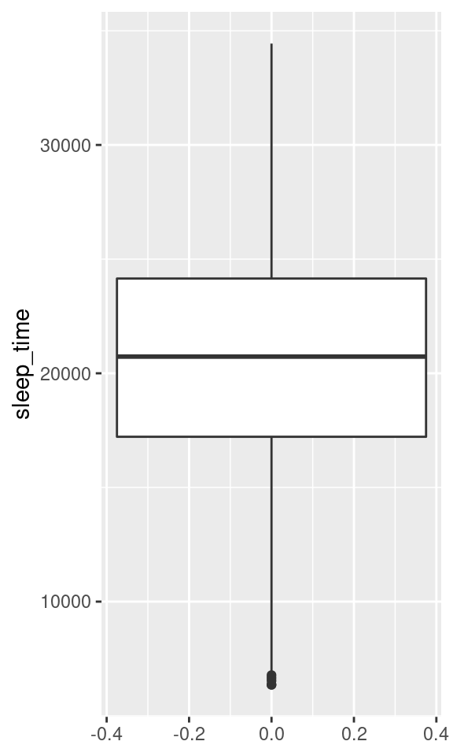

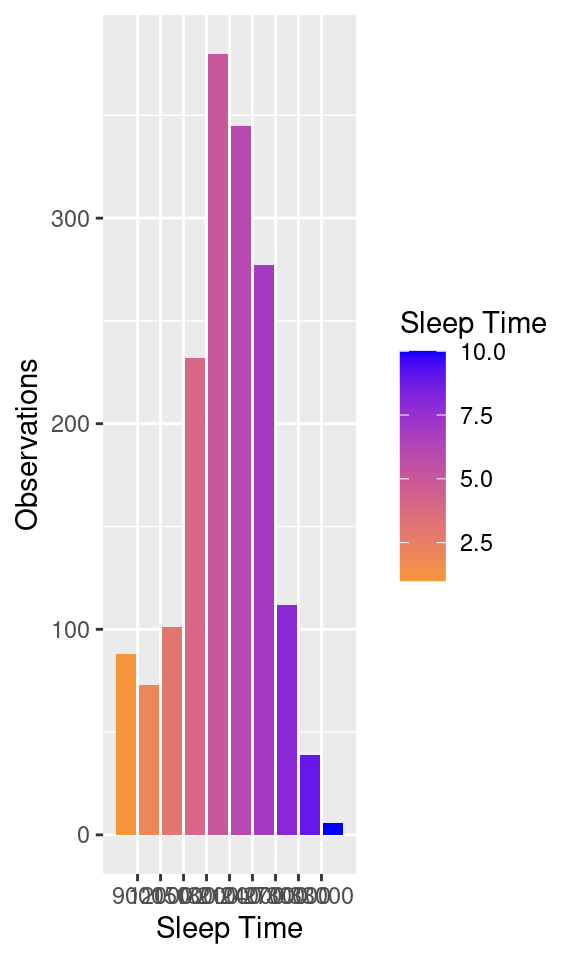

```
##    Min. 1st Qu.  Median    Mean 3rd Qu.    Max.
##    6360   17220   20730   20308   24150   34440
```

```r
fitness_data$narc_1600 <- replace_na(fitness_data$narc_1600, 0)
fitness_data$narc_1600[fitness_data$narc_1600 <= 3] <- 0
fitness_data$narc_1600[fitness_data$narc_1600 >= 3] <- 1
#If muscle weak occurs

fitness_data$soclhx_0900 <- replace_na(fitness_data$soclhx_0900,
                                       median(fitness_data$soclhx_0900, na.rm = T))
fitness_data$soclhx_0900[fitness_data$soclhx_0900 <= 2] <- 0
fitness_data$soclhx_0900[fitness_data$soclhx_0900 >= 1] <- 1
#caffeine


fitness_data$soclhx_0700 <- replace_na(fitness_data$soclhx_0700, 0)
#Number of alcoholic drink frequency


#fitness_data$soclhx_1320 <- replace_na(fitness_data$soclhx_1320, 0)
#cigarettes

fitness_data$soclhx_1500 <- replace_na(fitness_data$soclhx_1500, 0)
fitness_data$soclhx_1500[fitness_data$soclhx_1500 >= 1] <- 1
# Drug usage, 1 = drug user if ever used drugs
```

## What Determines “Quality” Sleep

- The Polysomnography file measured many variables, amongst which was the total amount of sleep time (sleep_time) of each participant
- A good sleeper has:
  - an above average sleep time (measured variables)
  - Epworth Sleep Scale below 16, meaning not severe excessive daytime sleepiness (subjective variable)
  - Felt more rested or the same as usual from polysomnography test (subjective variable)
  - less or same number of awakenings (measured variable)

## Data Wrangling

- A good sleeper will have on average \(117\) minutes of more sleep than a poor sleeper

```
##    good_sleeper avg_sleep_time count
## 1:            1       414.1342   529
## 2:            0       297.4194  1049
```

- We can oddly see that those who felt more rested on Polysomnography test slept for less amount of time (minutes)

```
##    compared_usual_feel_upon_awakening avg_sleep_time count
## 1:                        more_rested       291.6565   131
## 2:                        less_rested       307.4433   467
## 3:                               same       356.4153   980
```

## Visualizations

Visualizations were created through R’s default plot() function and the ggplot2 package

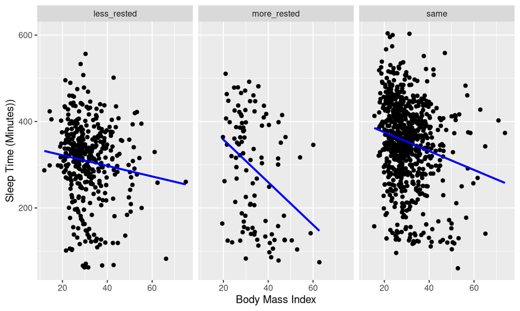

## Visualizations

Visualizations were created through R’s default plot() function and the ggplot2 package

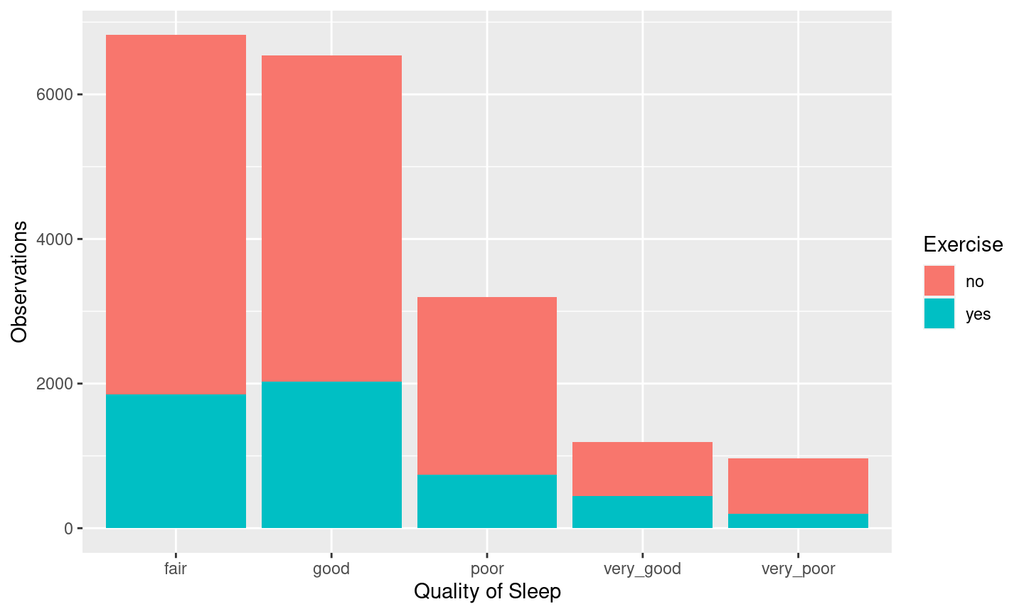

[output not shown]

## Modeling

- The first model we attempted was an extreme gradient boosted tree model from the XGBoost package. A boosted tree is a decision tree that achieves a high modelling accuracy by training new models to account for the training data that was previously incorrectly modeled.
- According to our XGB model, BMI, Epworth Sleepiness Scale, and the alcohol consumption are the predictors that provided the most gain to the model. It has an accuracy of \(60.34\%\), a specificity (true negative classification) of \(37.82\%\), and a sensitivity (true positive classification) of \(45\%\).

## Modeling

- The second model we used is K-nearest-neighbors. K nearest neighbors is a simple algorithm which searches for the closest (by distance) K neighbors to an observation for classification.
- Unfortunately, we are unable to determine feature importance from this model. It had an accuracy of \(58.01\%\), a sensitivity of \(38.39\%\), and a specificity of \(43.14\%\).

## Modeling

- The third model that we used is an elastic-net model. Elastic-net combines the strengths of the Ridge model, which is able to shrink down the coefficients of parameters to make them insignificant, and the LASSO model, which is able to completely remove parameters from the model.
- The elastic-net model achieved an accuracy of \(60.12\%\) the specificity (true negative classification) of \(43.24\%\), and a sensitivity (true positive classification), at around \(42.73\%\)
- According to the elastic-net model, the most significant predictors for a good sleeper are self perception of weight, family history of chronic fatigue, and caffeine consumption. Interestingly, the amount of exercise was deemed to be useless.

## Conclusion & Takeaways

- In the real world, datasets are not always “perfect” and much pre-cleaning needs to be done before it can be used for data analysis and modeling
- According to the data and our models, sleep and fitness have a less significant relationship than expected. However, this could also be due to how we defined someone who is fit and someone who is a good sleeper. Later studies should investigate this further.
- Despite finding data that was collected in a controlled environment, it is difficult to fully understand the scope and meaning of data without qualitative characteristics and context, and even more so with poor labeling and recording.

## Acknowledgements

This research has been conducted using the STAGES - Stanford Technology, Analytics and Genomics in Sleep Resource funded by the Klarman Family Foundation. The investigators of the STAGES study contributed to the design and implementation of the STAGES cohort and/or provided data and/or collected biospecimens, but did not necessarily participate in the analysis or writing of this report. The full list of STAGES investigators can be found at the project website.

The National Sleep Research Resource was supported by the U.S. National Institutes of Health, National Heart Lung and Blood Institute (R24 HL114473, 75N92019R002).

Thank You!